# BANA 7050 - Assignment Final

## Prophet Model

#### **Facebook Prophet Model :**

A facebook prophet model decomposes the time series data into multiple components : trend, seasonality and holidays. The trend component helps us understand the magnitude of change over time.The seasonality component helps us understand repeating patterns over fixed intervals , in our case it is yearly. This approach allows for flexible modeling of seasonal patterns and any irregular patterns in the data.

#### **Capturing trend and seasonality :**

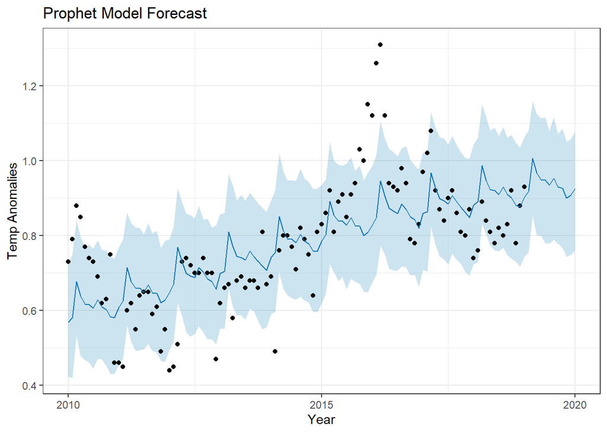

```r
library(prophet)

prophet_data = data_train %>%
    rename(ds = Year, # Have to name our date variable "ds"
    y = Value)  # Have to name our time series "y"

# train = prophet_data %>%  # Train set
#   filter(ds<ymd("2022-01-01"))
#
# test = prophet_data %>% # Test set
#   filter(ds>=ymd("2022-01-01"))

orig_model = prophet(prophet_data) # Train Model

orig_future = make_future_dataframe(orig_model,periods = 12,freq='month')

orig_forecast = predict(orig_model,orig_future) # Get forecast

plot(orig_model,orig_forecast)+
  ylab("Temp Anomalies")+
  xlab("Year")+
  theme_bw()+
  ggtitle("Prophet Model Forecast")
```

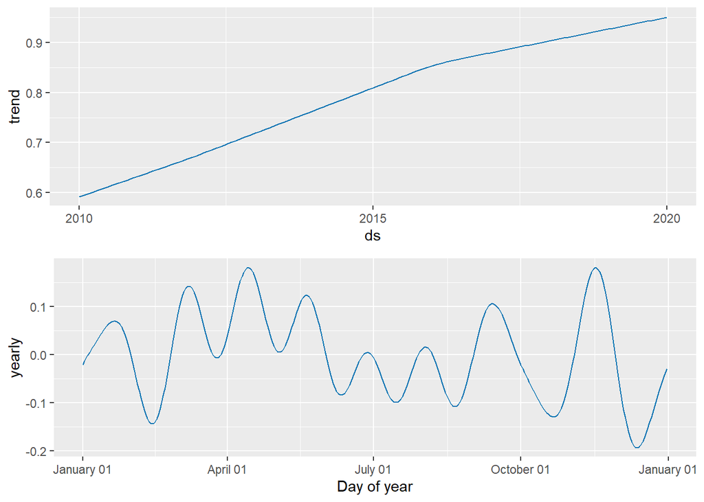

```r
prophet_plot_components(orig_model,orig_forecast)
```

**Model that is being considered: 25 Changepoints with linear growth**

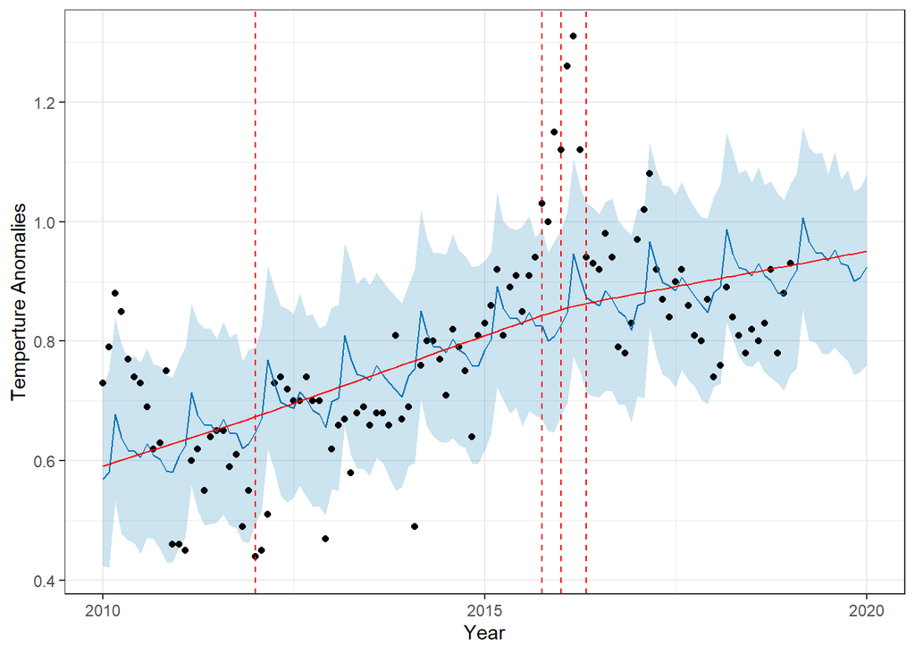

```r
plot(orig_model,orig_forecast) +
  add_changepoints_to_plot(orig_model) +
  theme_bw() +
  xlab("Year") +
  ylab("Temperture Anomalies")
```

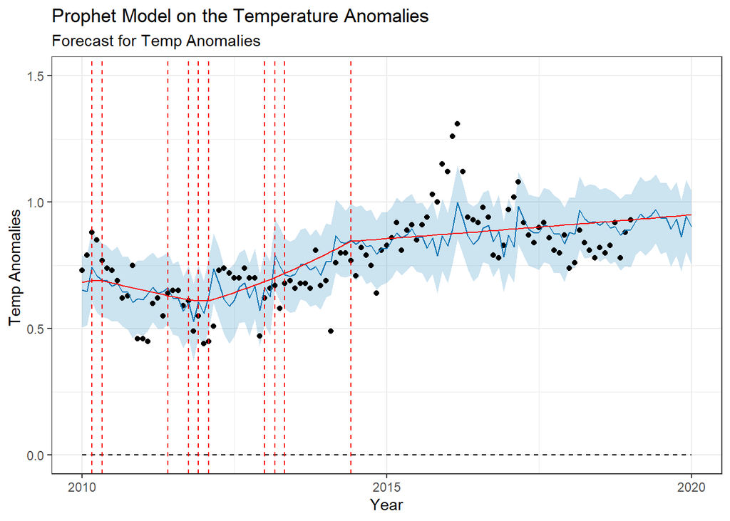

```r
prophet_data$cap = 150
prophet_data$floor = 0

log_future = orig_future %>%
  mutate(cap = 150, floor = 0)

log_model = prophet(prophet_data, growth = 'logistic',changepoint.prior.scale=0.5,n.changepoints = 25,changepoint.range=0.5, weekly.seasonality = FALSE, yearly.seasonality = TRUE, daily.seasonality = FALSE) # Logistic Growth Model

log_forecast = predict(log_model,log_future) # Get forecast

plot(log_model,log_forecast) +
  add_changepoints_to_plot(log_model)+
  ylab("Temp Anomalies ") +
  xlab("Year") +
  ylim(0,1.5)+
  theme_bw() +
  ggtitle("Prophet Model on the Temperature Anomalies"
    ,subtitle = "Forecast for Temp Anomalies "
  )
```

**Comparing additive and multiplicative Seasonality :**

Since we don’t have daily data, we do not have any impact due to holidays.

```r
mod1 = prophet(prophet_data,seasonality.mode='additive')
forecast1 = predict(mod1)

mod2 = prophet(prophet_data,seasonality.mode='multiplicative')
forecast2 = predict(mod2)

forecast_metric_data_add = forecast1 %>%
  as_tibble() %>%
  mutate(ds = as.Date(ds))

RMSE = sqrt(mean((prophet_data$y - forecast_metric_data_add$yhat)^2))

print(paste("RMSE for additive seasonality:",round(RMSE,2)))
```

```
[1] "RMSE for additive seasonality: 0.12"
```

```r
forecast_metric_data_multi = forecast2 %>%
  as_tibble() %>%
  mutate(ds = as.Date(ds))

RMSE = sqrt(mean((prophet_data$y - forecast_metric_data_multi$yhat)^2))

print(paste("RMSE for multiplicative seasonality:",round(RMSE,2)))
```

```
[1] "RMSE for multiplicative seasonality: 0.12"
```

```r
additive = prophet(prophet_data)
add_fcst = predict(additive,orig_future)
multi = prophet(prophet_data,seasonality.mode = 'multiplicative')
multi_fcst = predict(multi,orig_future)
df.cv <- cross_validation(additive, initial = 7*365, period = 30, horizon = 180, units = 'days')
#head(df.cv)

unique(df.cv$cutoff)
```

```
 [1] "2017-01-11 GMT" "2017-02-10 GMT" "2017-03-12 GMT" "2017-04-11 GMT"
 [5] "2017-05-11 GMT" "2017-06-10 GMT" "2017-07-10 GMT" "2017-08-09 GMT"
 [9] "2017-09-08 GMT" "2017-10-08 GMT" "2017-11-07 GMT" "2017-12-07 GMT"
[13] "2018-01-06 GMT" "2018-02-05 GMT" "2018-03-07 GMT" "2018-04-06 GMT"
[17] "2018-05-06 GMT" "2018-06-05 GMT" "2018-07-05 GMT"
```

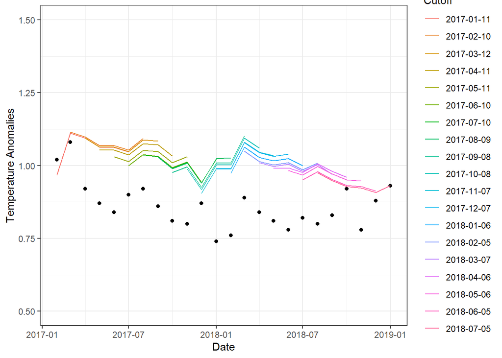

```r
df.cv %>%
  ggplot()+
  geom_point(aes(ds,y)) +
  geom_line(aes(ds,yhat,color=factor(cutoff)),size=0.5, alpha = 10)+
  theme_bw()+
  xlab("Date")+
  ylab("Temperature Anomalies")+
  scale_color_discrete(name = 'Cutoff')+
  ylim(0.5,1.5)
```

## Model Validation

In the first half our data, ARIMA does a good job of capturing the underlying trend but loses track eventually , whereas SNaive forecast does moderately well throughout and captures most of our significant anomalies.

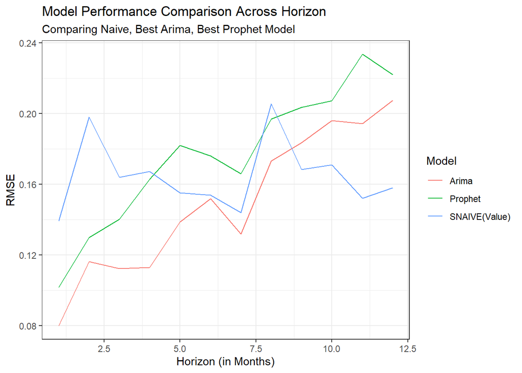

```r
train_cv <- data_train %>%
 as_tsibble() %>%
 stretch_tsibble(.init = 24, .step = 6)

naive_model <- train_cv %>%
 model(SNAIVE(Value)) %>%
 forecast(h = 12) %>%
 group_by(.id) %>%
 mutate(h = row_number()) %>%
 ungroup() %>%
 as_fable(response = "Value", distribution = Value)


 accuracy_naive <- naive_model %>%
 accuracy(as_tsibble(data_train), by = c("h", ".model"))

best_arima <- train_cv %>%
 model(
 Arima = ARIMA(log(Value),approximation=F)
 ) %>%
 forecast(h = 12) %>%
 group_by(.id) %>%
 mutate(h = row_number()) %>%
 ungroup() %>%
 as_fable(response = "Value", distribution = Value)
 accuracy_arima <- best_arima %>%
 accuracy(as_tsibble(data_train), by = c("h", ".model"))

best_prophet <- train_cv %>%
 model(
 Prophet = fable.prophet::prophet(Value ~ growth("linear", n_changepoints = 25, changepoint_range = 1,
 changepoint_prior_scale = 0.1))
 ) %>%
 forecast(h = 12) %>%
 group_by(.id) %>%
 mutate(h = row_number()) %>%
 ungroup() %>%
 as_fable(response = "Value", distribution = Value)

 accuracy_prophet <- best_prophet %>%
 accuracy(as_tsibble(data_train), by = c("h", ".model"))

 accuracy_comparison <- accuracy_naive %>%
 bind_rows(accuracy_arima) %>%
 bind_rows(accuracy_prophet)

 accuracy_comparison <- accuracy_comparison %>%
 rename(Horizon = h, Model = .model)

 accuracy_comparison %>%
 ggplot()+
 geom_line(aes(Horizon,RMSE, color = Model)) +
 theme_bw() +
 xlab("Horizon (in Months)") +
 ylab("RMSE") +
 ggtitle("Model Performance Comparison Across Horizon"
 ,subtitle = "Comparing Naive, Best Arima, Best Prophet Model"
 )
```

## Best Forecast :

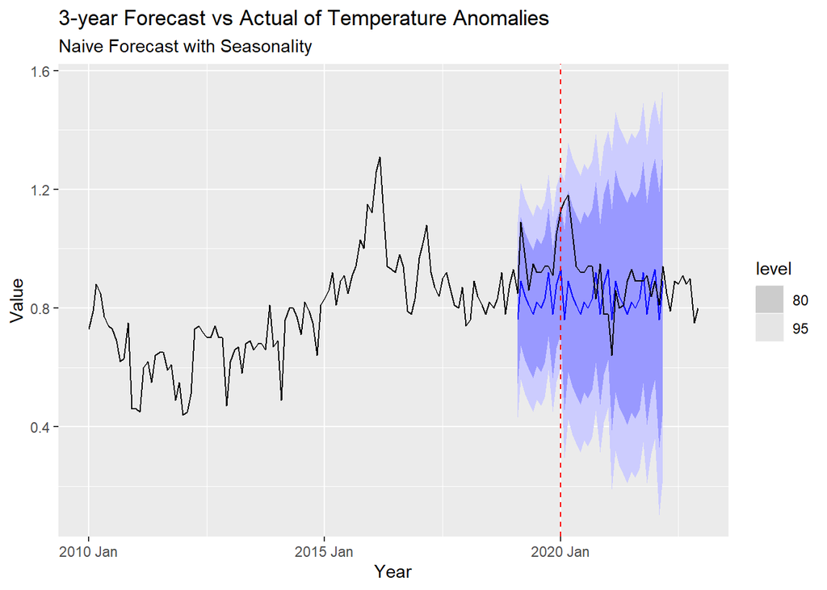

```r
best_model = data_train %>%
 as_tsibble() %>%
 model(SNAIVE(Value))
best_model %>%
 forecast(h=38) %>%
 autoplot(
 data_train %>%
 as_tsibble() %>%
 select(Year,Value) %>%
 bind_rows(
 data_test %>%
 as_tsibble() %>%
 select(Year,Value)
 )
 ) +
 geom_vline(aes(xintercept = ymd("2020-01-01")), color = "red", linetype = "dashed") +
 ggtitle("3-year Forecast vs Actual of Temperature Anomalies", subtitle = 'Naive Forecast with Seasonality')
```